# Diversity project new base file

This was getting exhausting, so we’re moving it to a repo now, so it can be properly versioned and edited and stuff, I got tired of all the duplicate files and the such. The lab notebook will simply contain notes…

This is mostly Amanda’s code, except that I noticed when trying to do tissue analyses that a lot of studies use the ‘source_name’ column to store tissue information, which is annoying but worth rescuing. Rather than trying to work out how to query the API programatically, which didn’t work so well, I am going to use her code to recreate the big master file, and then run it through the clean up process again with a couple of extra columns, and go from there.

```r
knitr::opts_knit$set(root.dir="~/OneDrive - St Vincent's Institute/Documents/RNA\ Diversity/SRA_metadata/", echo=T)
# But we also have to do this manually because R studio is stupid:
setwd(knitr::opts_knit$get("root.dir"))
library(plyr)
```

### Combine data extraction batches - pre 2019

```r
files1 <- paste0("0", seq(1:9))
files2 <- 10:15
files <- c(files1,files2)

sraPre <- read.csv('SRA_batches/SraRunTable_00.txt',header=T)

for (i in 1:length(files)){
  tmp_sub <- read.csv(paste('SRA_batches/SraRunTable_',files[i],'.txt',sep=''),header=T)
  sraPre <- rbind.fill(sraPre,tmp_sub)
  print(i)
}
```

```
## [1] 1
## [1] 2
## [1] 3
## [1] 4
## [1] 5
## [1] 6
## [1] 7
## [1] 8
## [1] 9
## [1] 10
## [1] 11
## [1] 12
## [1] 13
## [1] 14
## [1] 15
```

```r
dim(sraPre)
```

```
## [1] 355741    862
```

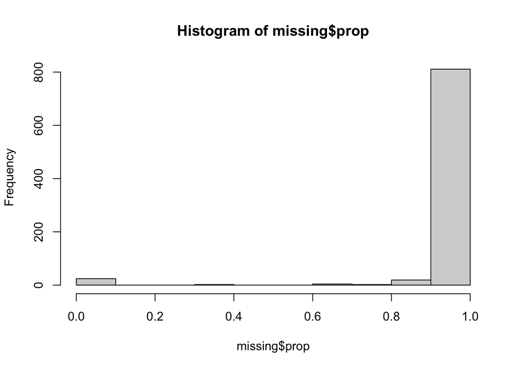

```r
missing <- as.data.frame(apply(sraPre,2,function(x) length(which(x=='' | is.na(x)))))
missing$prop <- missing[,1]/dim(sraPre)[1]
hist(missing$prop)
```

```r
write.table(as.data.frame((missing)),'missing_metadata_20240613.txt',quote=F,sep='\t')

# Most things are missing from most samples, because only one or two studies will use that particular column descriptor, epic:
nrow(missing)
```

```
## [1] 862
```

```r
nrow(missing[missing$prop >= 0.9,])/nrow(missing) # 94% of columns have > 90% missingness
```

```
## [1] 0.9408353
```

```r
head(missing[order(-missing$prop),])
```

```
##                       apply(sraPre, 2, function(x) length(which(x == "" | is.na(x))))
## media_ph                                                                       355663
## braf_mutation                                                                  355661
## nras_mutation                                                                  355661
## sepsis                                                                         355660
## replicate_description                                                          355659
## cell_lineage                                                                   355657
##                            prop
## media_ph              0.9997807
## braf_mutation         0.9997751
## nras_mutation         0.9997751
## sepsis                0.9997723
## replicate_description 0.9997695
## cell_lineage          0.9997639
```

```r
# What has no missingness/is mandatory?
nrow(missing[missing$prop <= 0.05,])/nrow(missing) #
```

```
## [1] 0.02784223
```

```r
head(missing[order(missing$prop),], n = 50) # Man, we're even missing some biosamples...
```

```
##                        apply(sraPre, 2, function(x) length(which(x == "" | is.na(x))))
## Run                                                                                  0
## Assay.Type                                                                           0
## Consent                                                                              0
## Experiment                                                                           0
## Instrument                                                                           0
## LibraryLayout                                                                        0
## LibrarySelection                                                                     0
## LibrarySource                                                                        0
## Platform                                                                             0
## ReleaseDate                                                                          0
## SRA.Study                                                                            0
## DATASTORE.filetype                                                                   2
## DATASTORE.provider                                                                   2
## DATASTORE.region                                                                     2
## Center.Name                                                                         18
## BioSample                                                                           83
## Organism                                                                            83
## Sample.Name                                                                         83
## Bytes                                                                              214
## AvgSpotLen                                                                         281
## Bases                                                                              281
## BioProject                                                                         688
## create_date                                                                       1245
## version                                                                           1245
## GEO_Accession..exp.                                                             119907
## source_name                                                                     126383
## Cell_type                                                                       218993
## Tissue                                                                          234952
## Library.Name                                                                    236427
## sex                                                                             247441
## Age                                                                             259703
## Cell_line                                                                       265976
## Sample_Name                                                                     293056
## ENA.FIRST.PUBLIC..run.                                                          293168
## ENA.LAST.UPDATE..run.                                                           293168
## INSDC_center_name                                                               296948
## INSDC_first_public                                                              296948
## INSDC_last_update                                                               296948
## INSDC_status                                                                    296948
```

[output cut: 47 more lines]

```
## INSDC_center_name      8.347309e-01
## INSDC_first_public     8.347309e-01
## INSDC_last_update      8.347309e-01
## INSDC_status           8.347309e-01
## INSDC_center_alias     8.355742e-01
## External_Id            8.360717e-01
## ENA.FIRST.PUBLIC       8.361533e-01
## ENA.LAST.UPDATE        8.361533e-01
## Submitter_Id           8.363697e-01
## common_name            8.409208e-01
## disease                8.460256e-01
## BIOMATERIAL_PROVIDER   8.580568e-01
## Isolate                8.624955e-01
## Treatment              8.672574e-01
## BioSampleModel         8.698266e-01
```

```r
# Some obvious places to find info that we care about:
names(sraPre)[grep("sample", names(sraPre), ignore.case=T)]
```

```
##  [1] "BioSample"                        "Sample.Name"
##  [3] "BioSampleModel"                   "Sample_type"
##  [5] "Sample_Name"                      "sample_term_id"
##  [7] "biosample_type"                   "seqc_sample"
##  [9] "number_of_cells_in_sample"        "Sample_Number"
## [11] "SampleNum"                        "Sample_ID"
## [13] "SAMPLE"                           "sampled_time_point"
## [15] "Sample_Description"               "SampleID"
## [17] "Sample_Group"                     "samplelabel"
## [19] "biospecimen_repository_sample_id" "host_tissue_sampled"
## [21] "sample_title"                     "samplename"
## [23] "Sample_code"
```

```r
names(sraPre)[grep("source", names(sraPre), ignore.case=T)]
```

```
##  [1] "LibrarySource"             "source_name"
##  [3] "Source"                    "source_material_cell_type"
##  [5] "source_material"           "Isolation_source"
##  [7] "tissue_source"             "tissue.cell_type_source"
##  [9] "reprogramming_source_cell" "source_tissue"
```

```r
names(sraPre)[grep("tissue", names(sraPre), ignore.case=T)]
```

```
## [1] "Tissue"                  "tissue_type"
## [3] "TISSUE_DEPOT"            "tissue_provider"
## [5] "tissue_lib"              "tissue_source"
## [7] "tissue.cell_type_source" "source_tissue"
## [9] "host_tissue_sampled"
```

```r
names(sraPre)[grep("population", names(sraPre), ignore.case=T)]
```

```
## [1] "predicted_population"
## [2] "Population"
## [3] "cell_subpopulation"
## [4] "cell_population"
## [5] "Experimental_Factor._population..exp."
## [6] "cell_populations"
```

```r
names(sraPre)[grep("country", names(sraPre), ignore.case=T)]
```

```
## [1] "geo_loc_name_country"           "geo_loc_name_country_continent"
## [3] "COUNTRY"
```

```r
names(sraPre)[grep("ancestry", names(sraPre), ignore.case=T)]
```

```
## [1] "ancestry"
```

```r
names(sraPre)[grep("race", names(sraPre), ignore.case=T)]
```

```
## [1] "RACE"          "reported_race"
```

```r
names(sraPre)[grep("ethnicity", names(sraPre), ignore.case=T)]
```

```
## [1] "DONOR_ETHNICITY" "ETHNICITY"
```

```r
# On the basis of that, I am picking some columns to keep after Amanda's originals:
head(sort(table(sraPre[!is.na(sraPre$Sample_type),]$Sample_type), decreasing=T), n = 20) # Keep
```

```
##
##
##                                        301279
##                                  cell culture
##                                          5648
##                        immortalized cell line
##                                          2200
##                                     cell line
##                                          1347
## Freshly isolated human fetal liver homegenate
##                                           995
##                                   single cell
##                                           973
##                                        tissue
##                                           770
##                                  primary cell
##                                           490
##                                   Solid tumor
##                                           483
##                       Fresh human hepatocytes
##                                           480
##                                  Primary Cell
##                                           475
##                                     total RNA
##                                           405
##                       single cell from tissue
##                                           368
##                               single cell RNA
##                                           349
##                                          FFPE
##                                           318
##                                  Ileal biopsy
##                                           310
##                                 tissue sample
##                                           269
##                 in vitro differentiated cells
##                                           196
##                                 needle biopsy
##                                           188
##                                  Cell culture
##                                           168
```

```r
head(sort(table(sraPre[!is.na(sraPre$biosample_type),]$biosample_type), decreasing=T), n = 20) # Reject
```

```
##
##                                                   cell line
##                         47692                           705
##                  primary cell in vitro differentiated cells
##                            73                            38
##                        tissue
##                            22
```

```r
head(sort(table(sraPre[!is.na(sraPre$SAMPLE),]$SAMPLE), decreasing=T), n = 20)
```

```
##
##        1304q1 1369q1 1659q1 2007q1  201q1 2226q1 3132q1 3758q1 4041q1 4203q1
##  34699      8      8      8      8      8      8      8      8      8      8
## 4243q1 4359q1 4445q2 4515q1 4606q1 4723q1 4749q1 4772q1 4797q1
##      8      8      8      8      8      8      8      8      8
```

```r
head(sort(table(sraPre[!is.na(sraPre$sample_title),]$sample_title), decreasing=T), n = 20)
```

```
##
##                    OTERT_LacZ     OTERT_OKP1     OTERT_OKP2       OTERT_P1
##          17261              4              4              4              4
##       OTERT_P2    16-153/0208    16-216/0509    16-293/0911    16-317/0412
##              4              3              3              3              3
##    16-346/0113    34-055/0311    34-065/0811 AML - 018/0513          SU001
##              3              3              3              3              3
##          SU014          SU018          SU028          SU041          SU042
##              3              3              3              3              3
```

```r
head(sort(table(sraPre[!is.na(sraPre$Sample_Group),]$Sample_Group), decreasing=T), n = 20)
```

```
##
##
##                                    15097
##                            ungrouped ALS
##                                       17
##                                  ALShigh
##                                       14
##                                  Control
##                                       14
##                                       C9
##                                       13
##                                   ALSlow
##                                        8
##                                     DDIS
##                                        8
##                                      FTD
##                                        8
##                                      RIS
##                                        8
## IPF (Idiopathic Pulmonary Fibrosis) HPFs
##                                        6
##                              Normal HPFs
##                                        6
##                            ungrouped FTD
##                                        6
##                                     SOD1
##                                        5
```

```r
head(sort(table(sraPre[!is.na(sraPre$samplename),]$samplename), decreasing=T), n = 20)
```

```
##
##                     20_Bcells        20_CD4T        20_CD8T   20_Monocytes
##          17339              1              1              1              1
## 20_Neutrophils          20_NK      20_Tempus      21_Bcells        21_CD4T
##              1              1              1              1              1
##        21_CD8T   21_Monocytes 21_Neutrophils          21_NK      21_Tempus
##              1              1              1              1              1
##      31_Bcells        31_CD4T        31_CD8T   31_Monocytes 31_Neutrophils
##              1              1              1              1              1
```

```r
head(sort(table(sraPre[!is.na(sraPre$host_tissue_sampled),]$host_tissue_sampled), decreasing=T), n = 20)
```

```
##
##                    whole larval cells   embryonated eggs
##              17152                268                 53
```

```r
head(sort(table(sraPre[!is.na(sraPre$source_name),]$source_name), decreasing=T), n = 20) # Defs keep
```

```
##
##                                                       Brain
##                        126383                          3932
##                   Whole blood                   Bone marrow
##                          3551                          2374
##                         Blood                          huh7
##                          2331                          2260
##                         Liver                        Cortex
##                          2220                          2128
##    Lin-CD34+CD38- bone marrow cultured embryonic stem cells
##                          2062                          1886
##            Cryopreserved PBMC    Lin-CD34+CD38+ bone marrow
##                          1617                          1600
##                        breast        acute myeloid leukemia
##                          1586                          1547
##                         serum                   whole blood
##                          1277                          1238
##                       T cells   breast cancer tissue (FFPE)
##                          1226                          1208
##                      ES cells                     cell line
##                          1188                          1042
```

```r
head(sort(table(sraPre[!is.na(sraPre$Source),]$Source), decreasing=T), n = 20)
```

```
##
##
##                                                      66247
##                                                       ATCC
##                                                       1428
##                                            Rush University
##                                                        180
##                                                   AllCells
##                                                        107
##                                     Yiing Lin\\, MD\\, PhD
##                                                         95
##                                        Dr. Masato Kanemaki
##                                                         92
##                                     The Jackson Laboratory
##                                                         66
##                                                      Lonza
##                                                         65
##                                       foreskin fibroblasts
##                                                         62
## Cells obtained from trachea of adult lung transplant donor
##                                                         61
##                                               David Hafler
##                                                         54
##                                                    Coriell
##                                                         38
##                                                      SESCC
##                                                         35
##                                                StemExpress
##                                                         34
##                                                 Job Dekker
##                                                         32
##                                               Paul Khavari
##                                                         32
##                                                 René Maehr
##                                                         30
##                                    John Stamatoyannopoulos
##                                                         23
##                                                      Sigma
##                                                         20
##          Cooper-Knock lab\\, University of Sheffield\\, UK
##                                                         18
```

```r
head(sort(table(sraPre[!is.na(sraPre$source_tissue),]$source_tissue), decreasing=T), n = 20) # Keep
```

```
##
##                  Peripheral Blood
##            16962              511
```

```r
head(sort(table(sraPre[!is.na(sraPre$source_material_cell_type),]$source_material_cell_type), decreasing=T), n = 20) # Keep
```

```
##
##            Fibroblast
##      15182        764
```

```r
head(sort(table(sraPre[!is.na(sraPre$source_material),]$source_material), decreasing=T), n = 20) # keep
```

```
##
##             Skin tissue
##       15182         764
```

```r
head(sort(table(sraPre[!is.na(sraPre$Isolation_source),]$Isolation_source), decreasing=T), n = 20)
```

```
##
##
##                                                      37076
##                                                     tissue
##                                                        347
##                                                     larvae
##                                                        268
##                                                    missing
##                                                          3
##                                             not applicable
##                                                          3
##                                    California\\, captivity
##                                                          2
##                                                       lung
##                                                          2
##                                                lung tissue
##                                                          2
##                                                   aquafarm
##                                                          1
##                                  Bahia Magdalena\\, Mexico
##                                                          1
##                        Chehalis River Enhancement Facility
##                                                          1
##                            From the lungs of infected mice
##                                                          1
##                                          Louisiana\\, wild
##                                                          1
##                                               ovary tissue
##                                                          1
## pooled from 200 male/female BALB/c mice\\, ages 8-12 weeks
##                                                          1
##                                 Southern Iberian Peninsula
##                                                          1
##                                          zhangzidao island
##                                                          1
```

```r
head(sort(table(sraPre[!is.na(sraPre$tissue_source),]$tissue_source), decreasing=T), n = 20) # Keep
```

```
##
##
##                                                                   109325
##                                          PBMCs from Mtb exposed patients
##                                                                      907
##                                                                    brain
##                                                                      784
##                                                           Tissue mixture
##                                                                       60
##                                            Modified liposuction aspirate
##                                                                       40
##                                                              bone marrow
##                                                                       30
##                                                               epithelium
##                                                                       30
##                                                         peripheral blood
##                                                                       30
##                                              Normal brain tissue mixture
##                                                                       20
## Captured in New South Wales, Australia (provided by Adelaide University)
##                                                                       18
##                     laser micro-dissected archival FFPE tissue specimens
##                                                                       18
##     Opossum colonies from the Museum of Natural History, Berlin, Germany
##                                                                       15
##                                 Facility of Linkoping University, Sweden
##                                                                       14
##                                              In house, C57BL7/6 colonies
##                                                                       14
##                   Lola ya Bonobo Sanctuary, Democratic Republic of Congo
##                                                                       12
##                                       Macaque facility in Souzhou, China
##                                                                       12
##                                           Commercial / AMS biotechnology
##                                                                       11
##                                                mid-gestation fetal brain
##                                                                       10
##                   Biomedical Primate Research Center, Netherlands (BPRC)
##                                                                        9
##                                                          Ascending Aorta
##                                                                        8
```

```r
head(sort(table(sraPre[!is.na(sraPre$tissue.cell_type_source),]$tissue.cell_type_source), decreasing=T), n = 20) # Keep
```

```
##
##                                          monocyte            breast cancer
##                    15030                       68                       60
## hepatocellular carcinoma
##                       52
```

```r
head(sort(table(sraPre[!is.na(sraPre$Organism_part),]$Organism_part), decreasing=T), n = 20) # Keep
```

```
##
##                                     decidua                dermis
##                322077                  7598                  4928
##                 blood              pancreas                  skin
##                  4702                  3533                  2433
##                embryo                 colon                spleen
##                  1732                  1153                  1042
##                tonsil        uterine cervix            lymph node
##                   398                   391                   382
##                retina  umbilical cord blood                kidney
##                   378                   370                   324
##                 liver                 brain       inner cell mass
##                   311                   274                   256
## mesenteric lymph node           bone marrow
##                   202                   177
```

```r
head(sort(table(sraPre[!is.na(sraPre$Sampling_site),]$Sampling_site), decreasing=T), n = 20) # Reject
```

```
##
##                                                                 right
##                              73220                                184
##                               left                             lesion
##                                152                                 93
##                           neoplasm   normal tissue adjacent to lesion
##                                 92                                 87
##                     terminal ileum                      normal tissue
##                                 68                                 23
##                   pleural effusion        peripheral zone of prostate
##                                 12                                  9
##        transition zone of prostate                            forearm
##                                  9                                  7
## normal tissue adjacent to neoplasm   normal tissue adjacent to tumour
##                                  7                                  6
##                               face                              scalp
##                                  5                                  5
##                                leg                                arm
##                                  3                                  2
```

```r
sraPreOld <- sraPre[,c('SRA.Study','Center.Name','BioSample','Organism','LibrarySource','Cell_type','Tissue','Cell_line','disease','ETHNICITY','disease_state','Diagnosis','tissue_type','clinical_information','RACE','Site','health_state','Population','tissue_source','geo_loc_name_country','geo_loc_name_country_continent','DONOR_HEALTH_STATUS','DONOR_ETHNICITY','geo_loc_name','reported_race','source_tissue',"ReleaseDate","create_date","ancestry","donor_id", "Sample_type", "source_name", "source_material_cell_type", "source_material", "tissue.cell_type_source", "tissue_source", "Organism_part")]

write.table(sraPreOld,'20240613_run_selector_metadata.txt',quote=F,row.names=F,sep='\t')
```

We cannot run everything in one go, so we split here like Amanda was doing, because otherwise we run out of RAM pretty quickly… But the process for combining is the same, and we do another round of checking for interesting columns

```r
newFiles<-seq(2:21)
sraPre <- read.csv('SRA_post2019/SraRunTable_1.txt',header=T)

for (i in 1:length(newFiles)){
  tmp_sub <- read.csv(paste('SRA_post2019/SraRunTable_',newFiles[i],'.txt',sep=''),header=T)
  sraPre <- rbind.fill(sraPre,tmp_sub)
  print(i)
}
```

```
## [1] 1
## [1] 2
## [1] 3
## [1] 4
## [1] 5
## [1] 6
## [1] 7
## [1] 8
## [1] 9
## [1] 10
## [1] 11
## [1] 12
## [1] 13
## [1] 14
## [1] 15
## [1] 16
## [1] 17
## [1] 18
## [1] 19
## [1] 20
```

```r
dim(sraPre)
```

```
## [1] 816157   1001
```

```r
# Missingness checks don't work here (out of ram) so we move straight to looking at some column names and labels:
names(sraPre)[grep("sample", names(sraPre), ignore.case=T)]
```

```
##  [1] "BioSample"
##  [2] "Sample.Name"
##  [3] "BioSampleModel"
##  [4] "SAMPLE_TYPE"
##  [5] "Sample_Name"
##  [6] "SAMPLE"
##  [7] "Sample_ID"
##  [8] "SAMPLE_NUMBER"
##  [9] "SampleID"
## [10] "biospecimen_repository_sample_id"
## [11] "Sample_Group"
## [12] "GENOMIC.LAB.SAMPLE.ID"
## [13] "sample_source"
## [14] "sample_title"
## [15] "sample_id_alt"
```

[output cut: 18 more lines]

```r
names(sraPre)[grep("source", names(sraPre), ignore.case=T)]
```

```
##  [1] "LibrarySource"           "source_name"
##  [3] "library_source"          "tissue_source"
##  [5] "source_tissue"           "Source"
##  [7] "tissue.cell_type_source" "source_materal_id"
##  [9] "cell_line_source"        "sample_source"
## [11] "Isolation_Source"        "source_organ"
## [13] "molecule_source"         "msc_source"
```

```r
names(sraPre)[grep("tissue", names(sraPre), ignore.case=T)]
```

```
##  [1] "Tissue"                       "tissue..run."
##  [3] "tissue_source"                "source_tissue"
##  [5] "tissue_type"                  "tissue_lib"
##  [7] "tissue_collection"            "tissue_processing"
##  [9] "tissue.cell_type_source"      "tissue_region"
## [11] "tissue.cell_type"             "tissue_compartment"
## [13] "Frozen_tissue"                "tissue_of_origin"
## [15] "tissue_composition"           "tissue.celltype"
## [17] "week_batch_tissue_collection"
```

```r
# No changes here:
names(sraPre)[grep("population", names(sraPre), ignore.case=T)]
```

```
## [1] "Population"
## [2] "cell_population"
## [3] "population_doublings_utotal_divisions"
## [4] "population_doubling_time_uhours_per_division"
```

```r
names(sraPre)[grep("country", names(sraPre), ignore.case=T)]
```

```
## [1] "geo_loc_name_country"           "geo_loc_name_country_continent"
```

```r
names(sraPre)[grep("ancestry", names(sraPre), ignore.case=T)]
```

```
## [1] "ancestry"
```

```r
names(sraPre)[grep("race", names(sraPre), ignore.case=T)]
```

```
## [1] "RACE"           "reported_race"  "primary_race"   "secondary_race"
## [5] "race.ethnicity"
```

```r
names(sraPre)[grep("ethnicity", names(sraPre), ignore.case=T)]
```

```
## [1] "ETHNICITY"      "race.ethnicity"
```

```r
# On the basis of that, I am picking some columns to keep after Amanda's originals:
head(sort(table(sraPre[!is.na(sraPre$sample_source),]$sample_source), decreasing=T), n = 20) # Reject
```

```
##
##                         Fresh  cryopreserved  O.N. cultured 6-day cultured
##          36532           2209           1168            407            105
## 2-day cultured
##             56
```

```r
head(sort(table(sraPre[!is.na(sraPre$Sample_material),]$Sample_material), decreasing=T), n = 20) # Reject
```

```
##
##                 tissue fragment cell suspension
##           47724             663               2
```

```r
head(sort(table(sraPre[!is.na(sraPre$sample.identity),]$sample.identity), decreasing=T), n = 20) # Reject
```

```
##
##          S1   S10  S100  S101  S102  S103  S104  S105  S106  S107  S108  S109
## 37239     1     1     1     1     1     1     1     1     1     1     1     1
##   S11  S110  S111  S112  S113  S114  S115
##     1     1     1     1     1     1     1
```

```r
head(sort(table(sraPre[!is.na(sraPre$sample_class),]$sample_class), decreasing=T), n = 20) # Reject
```

```
##
##          PRE LR  PRE SR POST LR POST SR
##   46343     148     128      44      44
```

```r
head(sort(table(sraPre[!is.na(sraPre$Sample.Name),]$Sample.Name), decreasing=T), n = 50) # Keep
```

```
##
## GSM4873766 GSM2970358 GSM2970359 GSM3449616 GSM3449613 GSM2970360 GSM2970361
##       5157       1331       1267       1171       1162       1143       1057
## GSM2970362 GSM2970363 GSM2970364 GSM3449615 GSM2970365 GSM2970366 GSM4154727
##        881        853        806        788        766        747        673
## GSM4154729 GSM4154728 GSM3449617 GSM2970367 GSM3449619 GSM4646858 GSM4656102
##        629        609        601        486        466        400        384
## GSM4656103 GSM4656104 GSM4656105 GSM4656106 GSM4656107 GSM4656108 GSM4656109
##        384        384        384        384        384        384        384
## GSM4656110 GSM4656111 GSM4656112 GSM5009530 GSM5009531 GSM5009532 GSM5009533
##        384        384        384        384        384        384        384
## GSM5009534 GSM5009535 GSM5009536 GSM5009537 GSM5009538 GSM5071638        SCI
##        384        384        384        384        384        384        376
## GSM4646857 GSM2970368 GSM2970369 GSM5071637 GSM3449614 GSM3449620 GSM3449618
##        360        350        307        281        278        246        221
## GSM4365547
##        200
```

```r
head(sort(table(sraPre[!is.na(sraPre$SAMPLE_TYPE),]$SAMPLE_TYPE), decreasing=T), n = 20) # Keep
```

```
##
##
##                                                                                            774905
##                                                                                      cell culture
##                                                                                              4302
##                                                                                       single cell
##                                                                                              3606
##                                                                                  200 single cells
##                                                                                              3200
##                                                                                       Single cell
##                                                                                              3103
##                                                                       normal fallopian tube cells
##                                                                                              1852
##                                                                                     tissue sample
##                                                                                              1215
##                                                                                         cell line
##                                                                                              1168
##                                                                                             serum
##                                                                                              1000
##                                                     Freshly isolated human fetal liver homegenate
##                                                                                               995
##                                                                                mixed cell culture
##                                                                                               777
##                                                                  breast cancer resection specimen
##                                                                                               768
##                                                                                 MoFlo sorted cell
##                                                                                               669
##                                                                                      Blood (PBMC)
##                                                                                               548
##                                                                                       Single Cell
##                                                                                               509
##                                                                                       ctc_cluster
##                                                                                               496
## cell sorted RNAseq from PBMC - for each sample CD4\\, CD14\\, CD19\\, and NK cells were sequenced
##                                                                                               480
##                                                                           Fresh human hepatocytes
##                                                                                               480
##                                                                                        ctc_single
##                                                                                               468
##                                                                                               RNA
##                                                                                               396
```

```r
head(sort(table(sraPre[!is.na(sraPre$sample_title),]$sample_title), decreasing=T), n = 20) # Reject
```

```
##
##
##                                                                       29034
##            RNA-seq_H1975_24h_F05_Idarubicin (Inhibitor_Antineoplastic)_0.26
##                                                                           1
##                       RNA-seq_H1975_24h_F06_CID 11210285 hydrochloride_0.14
##                                                                           1
##               RNA-seq_H1975_24h_F07_BIX 01294 trihydrochloride hydrate_1.94
##                                                                           1
##                                         RNA-seq_H1975_24h_F08_Orlistat_2.00
##                                                                           1
##                                        RNA-seq_H1975_24h_F09_Docetaxel_0.01
##                                                                           1
##                               RNA-seq_H1975_24h_F10_Sildenafil citrate_2.00
##                                                                           1
##                                RNA-seq_H1975_24h_F11_Lornoxicam (Xefo)_2.00
##                                                                           1
##                        RNA-seq_H1975_24h_F12_Benserazide hydrochloride_2.00
##                                                                           1
##                                            RNA-seq_H1975_24h_G01_PBIT_10.00
##                                                                           1
##                                       RNA-seq_H1975_24h_G02_Vandetanib_1.92
##                                                                           1
##   RNA-seq_H1975_24h_G03_PHA 767491 hydrochloride (Inhibitor_cdc7_cdk9)_2.60
##                                                                           1
##                                         RNA-seq_H1975_24h_G05_JFD00244_4.09
##                                                                           1
## RNA-seq_H1975_24h_G06_Podophyllotoxin (Inhibitor_Microtubule assembly)_0.04
##                                                                           1
##                RNA-seq_H1975_24h_G07_Tamoxifen citrate (Inhibitor_PKC)_6.50
##                                                                           1
##                                        RNA-seq_H1975_24h_G08_Amlexanox_2.00
##                                                                           1
##                                     RNA-seq_H1975_24h_G09_Lenalidomide_2.00
##                                                                           1
##                                         RNA-seq_H1975_24h_G10_Zileuton_2.00
##                                                                           1
##                                             RNA-seq_H1975_24h_G11_TAME_2.00
##                                                                           1
##               RNA-seq_H1975_24h_G12_Quinacrine dihydrochloride hydrate_1.94
##                                                                           1
```

```r
head(sort(table(sraPre[!is.na(sraPre$sample_origin),]$sample_origin), decreasing=T), n = 20) # Keep
```

```
##
##                 Engrafted tumor   Patient tumor
##           47724             567              98
```

```r
head(sort(table(sraPre[!is.na(sraPre$biosample_type),]$biosample_type), decreasing=T), n = 20) # Reject
```

```
##
##           cell line
##     37215       408
```

```r
head(sort(table(sraPre[!is.na(sraPre$source_name),]$source_name), decreasing=T), n = 20) # Defs keep
```

```
##
##
##                                                  151033
##                                                    PBMC
##                                                   12433
##                                                   iTreg
##                                                   11720
##                                       pancreatic islets
##                                                    9027
##                                                   Blood
##                                                    8029
##                                                  retina
##                                                    6567
## Isolated single cells from type-2 diabetes human islets
##                                                    6385
##                                             whole blood
##                                                    6082
##                                    human fallopian tube
##                                                    5797
##                                                    N_LV
##                                                    5159
##                                        Cerbellar nulcei
##                                                    5157
##                                                    N_LA
##                                                    4835
##                                                   blood
##                                                    4677
##                                        Psoriasis lesion
##                                                    4650
##                               PC9 lung cancer cell line
##                                                    4280
##                                 Pancreatic islets cells
##                                                    4224
##                                                   Tumor
##                                                    4100
##                                                   PBMCs
##                                                    4087
##                                             Whole blood
##                                                    3828
##                                                  Kidney
##                                                    3545
```

```r
head(sort(table(sraPre[!is.na(sraPre$library_source),]$library_source), decreasing=T), n = 20) # reject
```

```
##
##                  TRANSCRIPTOMIC transcriptomics
##           89810            2051             538
```

```r
head(sort(table(sraPre[!is.na(sraPre$tissue_source),]$tissue_source), decreasing=T), n = 20) # Keep
```

```
##
##
##                                   228676
##          PBMCs from Mtb exposed patients
##                                     1814
##                            Primary Tumor
##                                      957
##                                     Lung
##                                      654
##                Primmary Tissue Xenograft
##                                      239
##                             Fresh Tissue
##                                      172
##                               Lymph Node
##                                       96
##                                   breast
##                                       62
## High grade ovarian serous adenocarcinoma
##                                       62
##                           Tissue mixture
##                                       60
##                Invasive ductal carcinoma
##                                       54
##                                 foreskin
##                                       45
##              fresh embryo from Volunteer
##                                       44
##                                 Melanoma
##                                       30
##                                   Kidney
##                                       26
##                    fresh embryo from IVF
##                                       22
##              Normal brain tissue mixture
##                                       20
##                                   cervix
##                                       18
##                                     skin
##                                       18
##                                brain/CNS
##                                       17
```

```r
head(sort(table(sraPre[!is.na(sraPre$source_tissue),]$source_tissue), decreasing=T), n = 20) # Keep
```

```
##
##                  Peripheral Blood     Nasal Lavage
##            96104             1022              681
```

```r
head(sort(table(sraPre[!is.na(sraPre$tissue.cell_type_source),]$tissue.cell_type_source), decreasing=T), n = 20) # Keep
```

```
##
##                                          monocyte            breast cancer
##                    20085                       68                       60
## hepatocellular carcinoma
##                       52
```

```r
head(sort(table(sraPre[!is.na(sraPre$source_material_id),]$source_material_id), decreasing=T), n = 20) # Reject
```

```
## integer(0)
```

```r
head(sort(table(sraPre[!is.na(sraPre$cell_line_source),]$cell_line_source), decreasing=T), n = 20) # Reject
```

```
##
##
##                                                                69299
##                                               ATCC (Cat No CRL-1740)
##                                                                  144
##                                                          ATCC HTB-22
##                                                                  127
##                                        Derived from iPS line 657-GFP
##                                                                   30
##                                                                 A549
##                                                                   24
##                                                                H1299
##                                                                   24
##                                                                H1437
##                                                                   24
##                                                               Breast
##                                                                    6
##  Derived from the metastatic site, bone of a prostate cancer patient
##                                                                    6
## Derived from the metastatic site, brain of a prostate cancer patient
##                                                                    6
##                            esophageal squamous cell carcinoma (ESCC)
##                                                                    3
##                                                       Lymphoblastoid
##                                                                    3
##                                                                 Skin
##                                                                    3
##                        IMiD resistant cell line established from XG1
##                                                                    2
##           Myeloma cell line established before from a patient sample
##                                                                    2
##                                                          ATCC HTB-23
##                                                                    1
##                                                          ATCC HTB-24
##                                                                    1
##                                                          ATCC HTB-25
##                                                                    1
##                                                          ATCC HTB-26
##                                                                    1
##                                                          ATCC HTB-27
##                                                                    1
```

```r
head(sort(table(sraPre[!is.na(sraPre$cell_line_background),]$cell_line_background), decreasing=T), n = 20) # Reject
```

```
##
##                                     WM989-A6-G3-Cas9 5a3 melanoma cells
##                               43517                                 274
##                    CD0000011 (CD11)                              MCF10A
##                                  20                                   9
##                             HCC1806                               JIMT1
##                                   8                                   8
##                               22Rv1                                V16A
##                                   6                                   6
##                    CD0000021 (CD21)                             HCC1954
##                                   4                                   4
##                            MDAMB231
##                                   3
```

```r
head(sort(table(sraPre[!is.na(sraPre$source_organ),]$source_organ), decreasing=T), n = 20) # Keep
```

```
##
##       Heart heart
## 43287   502    70
```

```r
head(sort(table(sraPre[!is.na(sraPre$Sampling_site),]$Sampling_site), decreasing=T), n = 20) # Keep
```

```
##
##                                                             xenograft
##                             153957                                468
##                           neoplasm normal tissue adjacent to neoplasm
##                                425                                117
##                               lung                            occiput
##                                 68                                 40
##                             vertex                              liver
##                                 40                                 29
##                            bladder                       whole tumour
##                                 22                                 20
##                             breast                              colon
##                                 19                                 19
##                             tumour                      stromal cells
##                                 19                                 17
##                     cardiac atrium                               knee
##                                 15                                 15
##                         lymph node                   dorsal optic cup
##                                 15                                 12
##    normal tissue adjacent to tumor              optic fissure margins
##                                 12                                 12
```

```r
sraPreNew <- sraPre[,c('SRA.Study','Center.Name','BioSample','Organism','LibrarySource','Cell_type','Tissue','Cell_Line','disease','ETHNICITY','disease_state','Diagnosis','tissue_type','clinical_information','RACE','Site','health_state','Population','tissue_source','geo_loc_name_country','geo_loc_name_country_continent','geo_loc_name','reported_race','source_tissue',"ReleaseDate","create_date","ancestry","race.ethnicity","primary_race",'geographical_location',"donor_id", "source_name", "source_materal_id", "tissue_source", "SAMPLE_TYPE", "sample_origin", "tissue.cell_type_source", "source_organ", "Sampling_site", "Organism_part")]

write.table(sraPreNew,'20240613_run_selector_metadata_post2019.txt',quote=F,row.names=F,sep='\t')
```

Anything after donor_id in either call is newly added right now, and the merger still works, although here it is more of a sanity check than anything else.

```r
#########
# combine ALL samples from pre and post 2019
#########

names(sraPreNew)[8] <- "Cell_line"

allSRA <- rbind.fill(sraPreNew, sraPreOld)
dim(allSRA)
```

```
## [1] 1171898      45
```

```r
allSRA <- allSRA[allSRA$Organism == "Homo sapiens" & allSRA$LibrarySource== "TRANSCRIPTOMIC",]
dim(allSRA) # Yep that cleaned things up
```

```
## [1] 1121872      45
```

```r
allSRAcounts <- as.data.frame(table(allSRA$SRA.Study))
keepStudies <- allSRAcounts[allSRAcounts$Freq >= 10,]
allSRAFilt <- allSRA[allSRA$SRA.Study %in% keepStudies$Var1,]
dim(allSRAFilt) # Most of them stick around...
```

```
## [1] 1079533      45
```